# Base R Plotting

GEOG 693g

Amy Hessl

12 November, 2019

### Motivation

Finally Sandra has her data all munged and ready to explore. How can she get started making some figures that can be recreated later, just in case she needs to update her data? How can she remake these figures for publication at the right resolution and size required by her journal?

### Questions

*How can I create simple X-Y plots in base R?*  
How can I create my own plots in base R with fine control?  
*How can I plot multiple graphs on a page?*  
How can I add marginal plots?  
*How can I plot graphs on top of each other (2 y-axes)?

### Objectives

Develop some basic skills in X-Y plotting typical of exploratory data analysis.

### R Functions

- summary() - provides basic summary stats for every variable (column) in data frame
- attach() - database or object attached to the R search path which allows you to call variables without indicating the data frame first.
- plot() - baseR plotting X-Y plots (scatter, line, stair-step etc)
- color palette - a set of pre-selected colors. Great for folks with limited artistic abilities.

### Base R Plotting is Fun

Using the original gapminder dataset, let’s make a bubble plot of life expectancy, income and population.

```r
gap <- read.csv("../data/gapminder.csv")
summary(gap)
```

```
##        X                 country        continent        year
##  Min.   :   1.0   Afghanistan:  12   Africa  :624   Min.   :1952
##  1st Qu.: 426.8   Albania    :  12   Americas:300   1st Qu.:1966
##  Median : 852.5   Algeria    :  12   Asia    :396   Median :1980
##  Mean   : 852.5   Angola     :  12   Europe  :360   Mean   :1980
##  3rd Qu.:1278.2   Argentina  :  12   Oceania : 24   3rd Qu.:1993
##  Max.   :1704.0   Australia  :  12                  Max.   :2007
##                   (Other)    :1632
##     lifeExp           pop              gdpPercap
##  Min.   :23.60   Min.   :6.001e+04   Min.   :   241.2
##  1st Qu.:48.20   1st Qu.:2.794e+06   1st Qu.:  1202.1
##  Median :60.71   Median :7.024e+06   Median :  3531.8
##  Mean   :59.47   Mean   :2.960e+07   Mean   :  7215.3
##  3rd Qu.:70.85   3rd Qu.:1.959e+07   3rd Qu.:  9325.5
##  Max.   :82.60   Max.   :1.319e+09   Max.   :113523.1
##
```

Let’s extract the most recent year of data:

```r
gap_07 <- gap[gap$year==2007,]
```

Let’s make a simple scatter plot of lifeExp vs gdpPercap

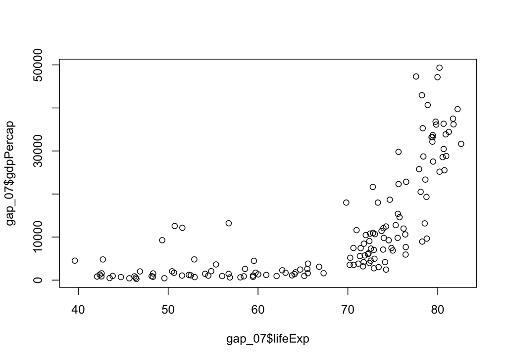

```r
plot(gap_07$lifeExp, gap_07$gdpPercap, type="p")
```

We need to transform these data!

```r
summary(gap_07)
```

```
##        X               country       continent       year
##  Min.   :  12   Afghanistan:  1   Africa  :52   Min.   :2007
##  1st Qu.: 435   Albania    :  1   Americas:25   1st Qu.:2007
##  Median : 858   Algeria    :  1   Asia    :33   Median :2007
##  Mean   : 858   Angola     :  1   Europe  :30   Mean   :2007
##  3rd Qu.:1281   Argentina  :  1   Oceania : 2   3rd Qu.:2007
##  Max.   :1704   Australia  :  1                 Max.   :2007
##                 (Other)    :136
##     lifeExp           pop              gdpPercap
##  Min.   :39.61   Min.   :1.996e+05   Min.   :  277.6
##  1st Qu.:57.16   1st Qu.:4.508e+06   1st Qu.: 1624.8
##  Median :71.94   Median :1.052e+07   Median : 6124.4
##  Mean   :67.01   Mean   :4.402e+07   Mean   :11680.1
##  3rd Qu.:76.41   3rd Qu.:3.121e+07   3rd Qu.:18008.8
##  Max.   :82.60   Max.   :1.319e+09   Max.   :49357.2
##
```

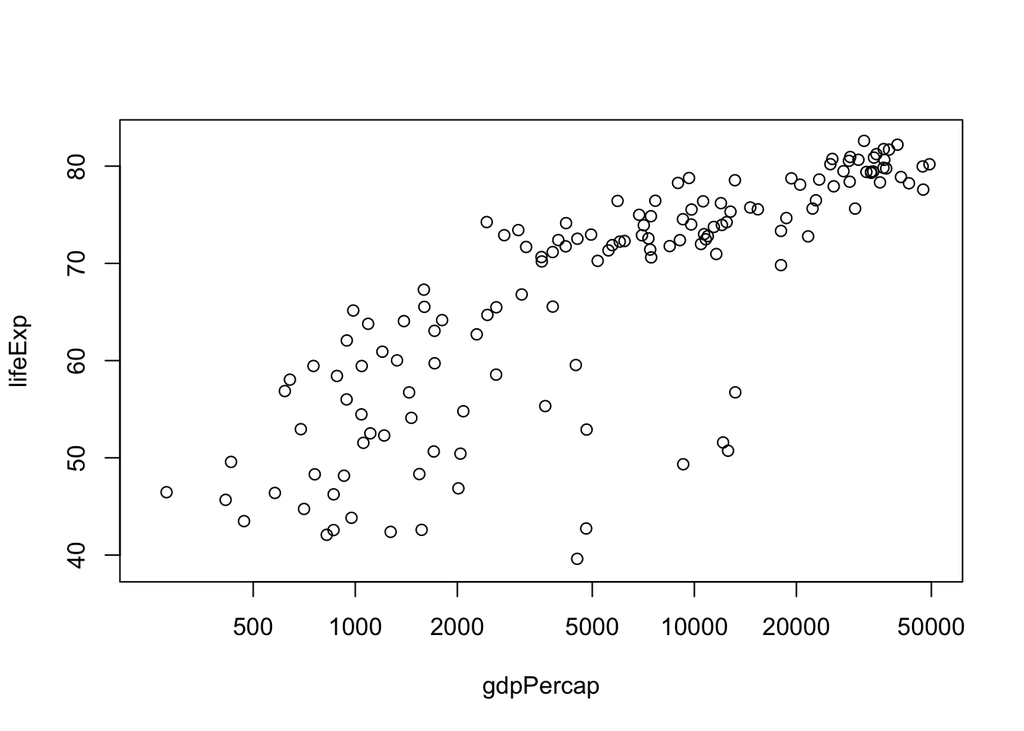

```r
jXlim <- c(250, 50000)
jYlim <- c(39, 83)
attach(gap_07)
plot(lifeExp ~ gdpPercap, log = 'x', xlim = jXlim, ylim = jYlim)
```

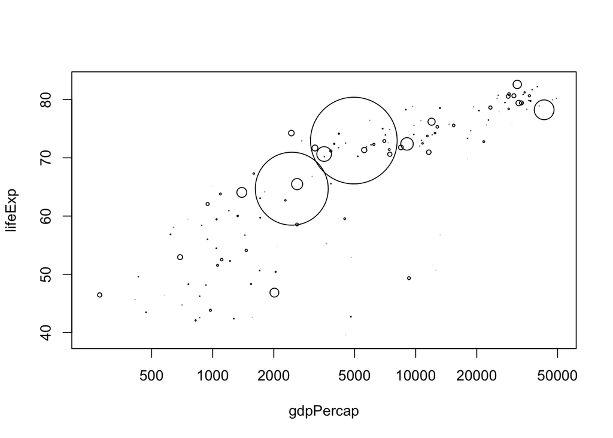

```r
plot(lifeExp ~ gdpPercap, log = 'x', xlim = jXlim, ylim = jYlim, cex=pop/1e+08)
```

Better, how about we color the symbols based on continent? There are lots of color palletes created in R already - I stick with those! Here we display what a pallete of 5 colors would look like, then save the colors as a dataframe for future use. () allows us to display the dataframe as well as save it

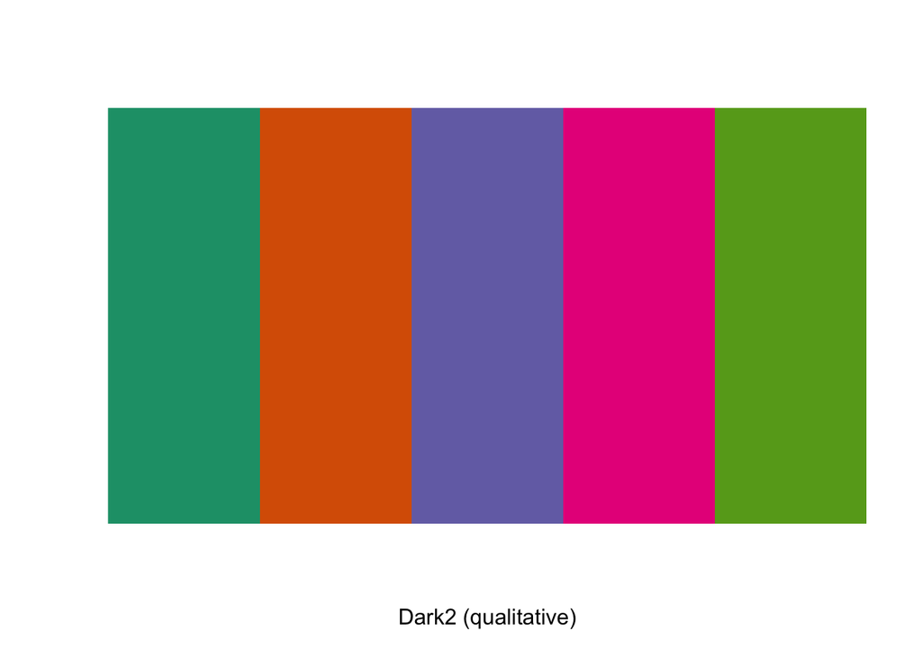

```r
library(RColorBrewer)
display.brewer.pal(5, "Dark2")
```

```r
(contCB <-
   with(gap_07,
        data.frame(continent = levels(continent),
                   color = I(brewer.pal(nlevels(continent), name = 'Dark2')))))
```

```
##   continent   color
## 1    Africa #1B9E77
## 2  Americas #D95F02
## 3      Asia #7570B3
## 4    Europe #E7298A
## 5   Oceania #66A61E
```

With intention, this data.frame has a factor continent with the same name as the continent factor in jDat and with the same levels, in the same order. I am also using inhibit, I(), to protect the color-specifying hex strings from being converted to factor.

Now we can see how we might match the data in the color dataframe to the gapminder ‘continent’ variable.

```r
head(data.frame(subset(gap_07, select = c(country, continent)),
           matchRetVal = match(gap_07$continent, contCB$continent)))
```

```
##        country continent matchRetVal
## 12 Afghanistan      Asia           3
## 24     Albania    Europe           4
## 36     Algeria    Africa           1
## 48      Angola    Africa           1
## 60   Argentina  Americas           2
## 72   Australia   Oceania           5
```

Now I can use the match() results to index onto the color variable of my color scheme. That creates the vector of colors I need for the col = argument of plot().

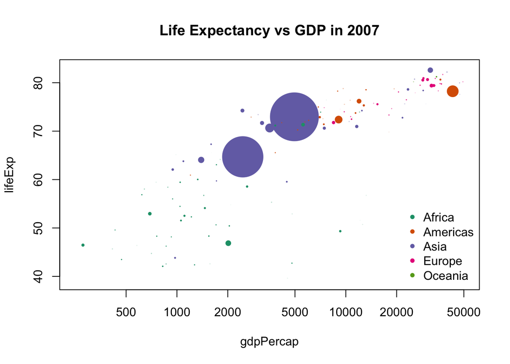

```r
plot(lifeExp ~ gdpPercap, log = 'x', xlim = jXlim, ylim = jYlim,
     cex=pop/1e+08, pch=20,
     col = contCB$color[match(gap_07$continent, contCB$continent)],
     main = 'Life Expectancy vs GDP in 2007')
legend(x = 'bottomright',
       legend = as.character(contCB$continent),
       col = contCB$color, pch = 20, bty = 'n', xjust = 1)
```

Nearly there - I don’t like the way we scaled the population variable. Let’s create a function that calculates the percentiles for each country and use that to scale.

```r
perc.rank <- function(x) trunc(rank(x))/length(x)
gap_07$popPerc <- perc.rank(pop)
attach(gap_07)
```

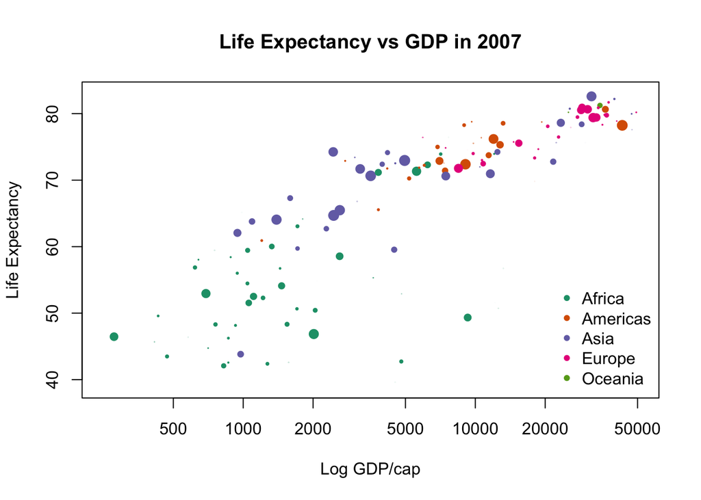

```r
plot(lifeExp ~ gdpPercap, log = 'x', xlim = jXlim, ylim = jYlim,
     cex=(popPerc^2)*2, pch=20,
     col = contCB$color[match(gap_07$continent, contCB$continent)],
     main = 'Life Expectancy vs GDP in 2007',
     ylab='Life Expectancy', xlab='Log GDP/cap')
legend(x = 'bottomright',
       legend = as.character(contCB$continent),
       col = contCB$color, pch = 20, bty = 'n', xjust = 1, y.intersp = 1)
```

Oh I don’t know! Come up with your own way to represent the values!

Finally, let’s select some of the symbols and display a label for it.

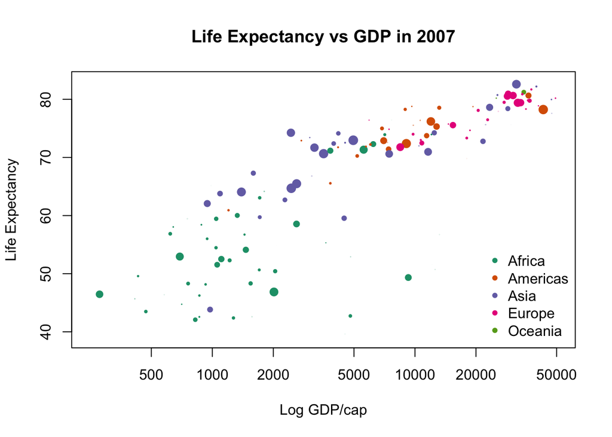

```
## integer(0)
```

```r
plot(lifeExp ~ gdpPercap, log = 'x', xlim = jXlim, ylim = jYlim,
     cex=(popPerc^2)*2, pch=20,
     col = contCB$color[match(gap_07$continent, contCB$continent)],
     main = 'Life Expectancy vs GDP in 2007',
     ylab='Life Expectancy', xlab='Log GDP/cap')
legend(x = 'bottomright',
       legend = as.character(contCB$continent),
       col = contCB$color, pch = 20, bty = 'n', xjust = 1, y.intersp = 1.0)
identify(lifeExp ~ gdpPercap, labels=country)
```

### Add a Regression Line and Expression to Plot

First, create a regression model to add:

```r
splm <- lm(mpg~wt, data=mtcars)
summary.lm(splm)
```

```
##
## Call:
## lm(formula = mpg ~ wt, data = mtcars)
##
## Residuals:
##     Min      1Q  Median      3Q     Max
## -4.5432 -2.3647 -0.1252  1.4096  6.8727
##
## Coefficients:
##             Estimate Std. Error t value Pr(>|t|)
## (Intercept)  37.2851     1.8776  19.858  < 2e-16 ***
## wt           -5.3445     0.5591  -9.559 1.29e-10 ***
## ---
## Signif. codes:  0 '***' 0.001 '**' 0.01 '*' 0.05 '.' 0.1 ' ' 1
##
## Residual standard error: 3.046 on 30 degrees of freedom
## Multiple R-squared:  0.7528, Adjusted R-squared:  0.7446
## F-statistic: 91.38 on 1 and 30 DF,  p-value: 1.294e-10
```

```r
adj.r <- round(summary.lm(splm)$adj.r.square, 4)
```

Next, use that formula to plot the line:

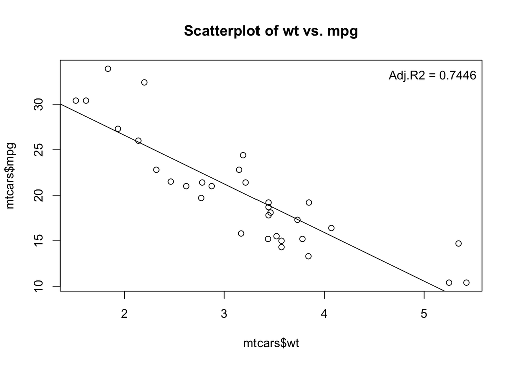

```r
plot(mtcars$wt,mtcars$mpg, main="Scatterplot of wt vs. mpg")
abline(reg = splm) #abline(coef=coef(splm))
legend("topright", paste0("Adj.R2 = ", adj.r), bty='n')
```

### Combining Plots

R makes it easy to combine multiple plots into one overall graph, using either the par( ) or layout( ) function.

With the par( ) function, you can include the option mfrow=c(nrows, ncols) to create a matrix of nrows x ncols plots that are filled in by row. mfcol=c(nrows, ncols) fills in the matrix by columns.

##### *Before altering par, always save the defaults*

```r
head(par())
```

```
## $xlog
## [1] FALSE
##
## $ylog
## [1] FALSE
##
## $adj
## [1] 0.5
##
## $ann
## [1] TRUE
##
## $ask
## [1] FALSE
##
## $bg
## [1] "white"
```

```r
def.par <- par()
```

#### Arrange Four Figures in One Plot

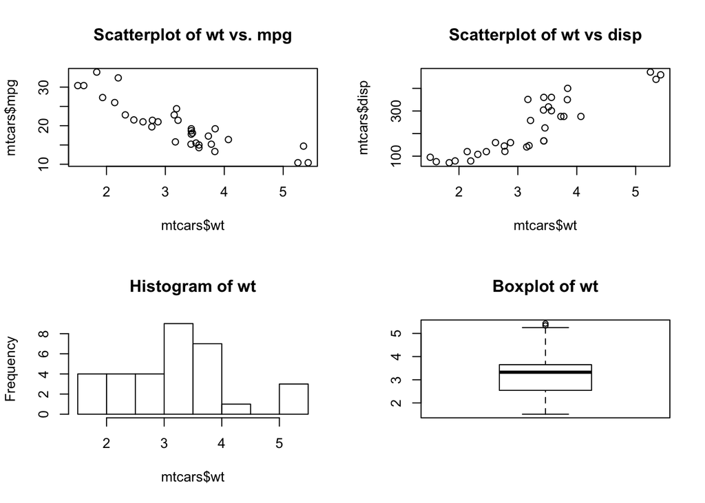

```r
par(mfrow=c(2,2))
plot(mtcars$wt, mtcars$mpg, main="Scatterplot of wt vs. mpg")
plot(mtcars$wt, mtcars$disp, main="Scatterplot of wt vs disp")
hist(mtcars$wt, main="Histogram of wt")
boxplot(mtcars$wt, main="Boxplot of wt")
```

#### Stack Three Figures as 3 rows and 1 column

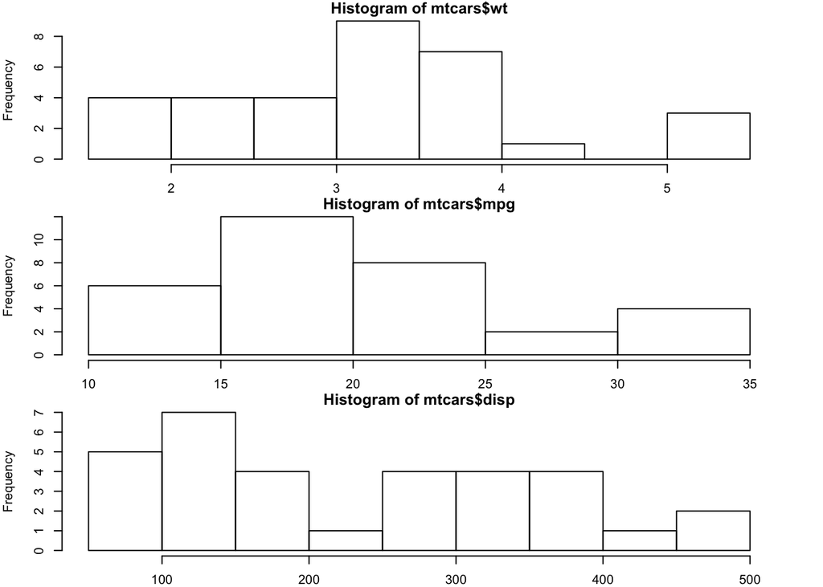

```r
par(mfrow=c(3,1), mar=c(2, 4, 1, 3))
hist(mtcars$wt)
hist(mtcars$mpg)
hist(mtcars$disp)
```

```r
par <- par(def.par)
```

The layout( ) function has the form layout(mat) where mat is a matrix object specifying the location of the N figures to plot.

#### Asymmetrical: One figure in row 1 and two figures in row 2

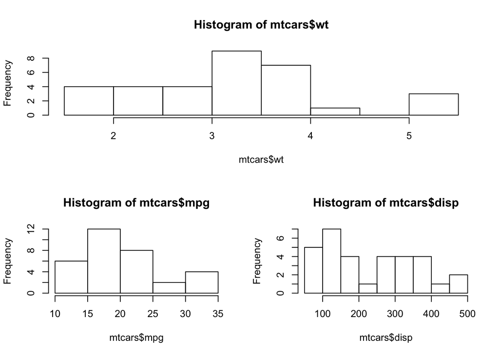

```r
layout(matrix(c(1,1,2,3), 2, 2, byrow = TRUE))
hist(mtcars$wt)
hist(mtcars$mpg)
hist(mtcars$disp)
```

Optionally, you can include widths= and heights= options in the layout( ) function to control the size of each figure more precisely. These options have the form widths= a vector of values for the widths of columns heights= a vector of values for the heights of rows.

Relative widths are specified with numeric values. Absolute widths (in centimetres) are specified with the lcm() function.

#### One figure in row 1 and two figures in row 2

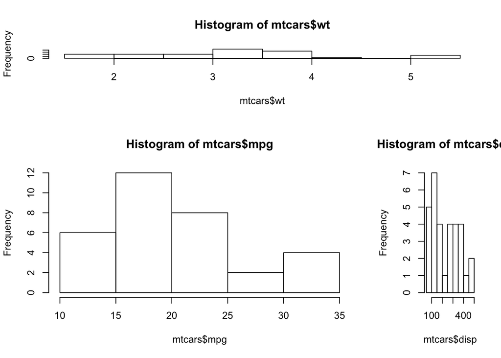

```r
layout(matrix(c(1,1,2,3), 2, 2, byrow = TRUE),
    widths=c(3,1), heights=c(1,2))
hist(mtcars$wt)
hist(mtcars$mpg)
hist(mtcars$disp)
```

See help(layout) for more details.

#### Creating a figure arrangement with fine control

In the following example, two box plots are added to scatterplot to create an enhanced graph by setting the par(fig=c(x1, x2, y1, y2)) coordinates in the figure region. Must use par(new=TRUE) in order to draw over same plot region each time.

Add boxplots to a scatterplot

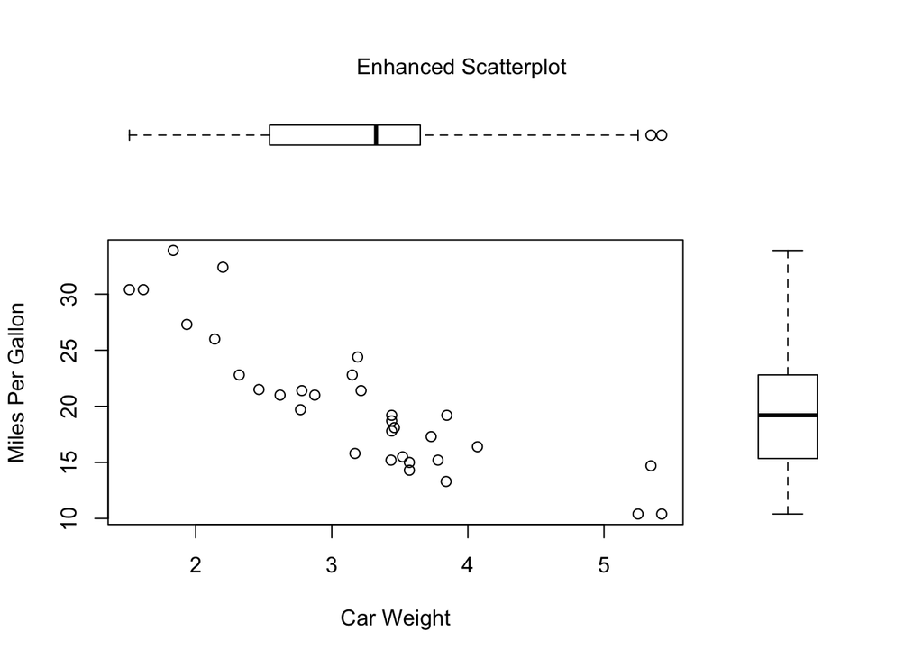

```r
par(fig=c(0,0.8,0,0.8), new=TRUE)
plot(mtcars$wt, mtcars$mpg, xlab="Car Weight",
  ylab="Miles Per Gallon")
par(fig=c(0,0.8,0.55,1), new=TRUE)
boxplot(mtcars$wt, horizontal=TRUE, axes=FALSE)
par(fig=c(0.65,1,0,0.8),new=TRUE)
boxplot(mtcars$mpg, axes=FALSE)
mtext("Enhanced Scatterplot", side=3, outer=TRUE, line=-3)
```

To understand this graph, think of the full graph area as going from (0,0) in the lower left corner to (1,1) in the upper right corner. The format of the fig= parameter is a numerical vector of the form c(x1, x2, y1, y2). The first fig= sets up the scatterplot going from 0 to 0.8 on the x axis and 0 to 0.8 on the y axis. The top boxplot goes from 0 to 0.8 on the x axis and 0.55 to 1 on the y axis. I chose 0.55 rather than 0.8 so that the top figure will be pulled closer to the scatter plot. The right hand boxplot goes from 0.65 to 1 on the x axis and 0 to 0.8 on the y axis. Again, I chose a value to pull the right hand boxplot closer to the scatterplot. You have to experiment to get it just right.

fig= starts a new plot, so to add to an existing plot use new=TRUE.

#### Plotting Multiple Time Series

```r
temps <- read.csv("https://data.giss.nasa.gov/gistemp/graphs/graph_data/Hemispheric_Temperature_Change/graph.csv")

head(temps[,1:4])
```

```
##   Year  Glob  NHem  SHem
## 1 1880 -0.16 -0.28 -0.05
## 2 1881 -0.08 -0.16  0.00
## 3 1882 -0.10 -0.20 -0.01
## 4 1883 -0.17 -0.27 -0.07
## 5 1884 -0.28 -0.43 -0.15
## 6 1885 -0.32 -0.41 -0.25
```

```r
summary(temps[,1:4])
```

```
##       Year           Glob               NHem              SHem
##  Min.   :1880   Min.   :-0.48000   Min.   :-0.5700   Min.   :-0.49000
##  1st Qu.:1914   1st Qu.:-0.21000   1st Qu.:-0.2150   1st Qu.:-0.22000
##  Median :1949   Median :-0.07000   Median :-0.0200   Median :-0.07000
##  Mean   :1949   Mean   : 0.03547   Mean   : 0.0605   Mean   : 0.01079
##  3rd Qu.:1984   3rd Qu.: 0.21000   3rd Qu.: 0.2100   3rd Qu.: 0.26500
##  Max.   :2018   Max.   : 1.01000   Max.   : 1.3100   Max.   : 0.73000
```

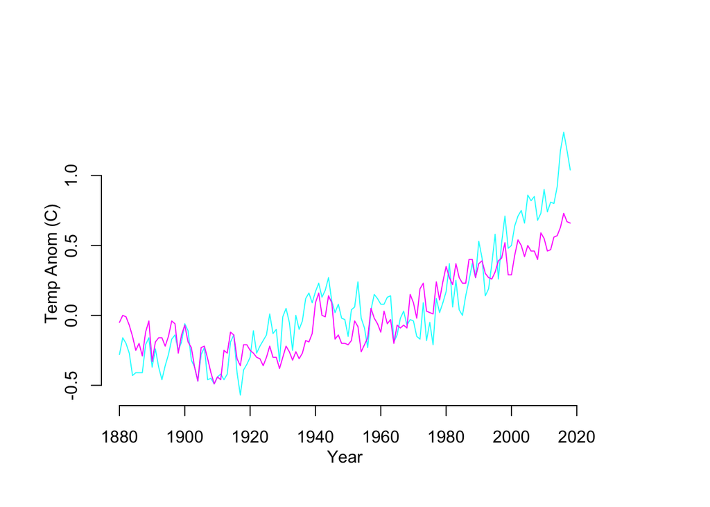

```r
 par(oma=c(0,1,1,3), mar=c(5,4,5,3))
    plot(temps$Year, temps$NHem, type='l', axes=F, xlab='', ylab='', col="cyan")
    axis(1, seq(1880, 2020, by=20))
    mtext(side=1, "Year", line=2)
    axis(2, seq(-0.5, 1.3, by=0.5))
    mtext(side=2, "Temp Anom (C)", line=2)

    lines(temps$Year, temps$SHem, col="magenta")
```

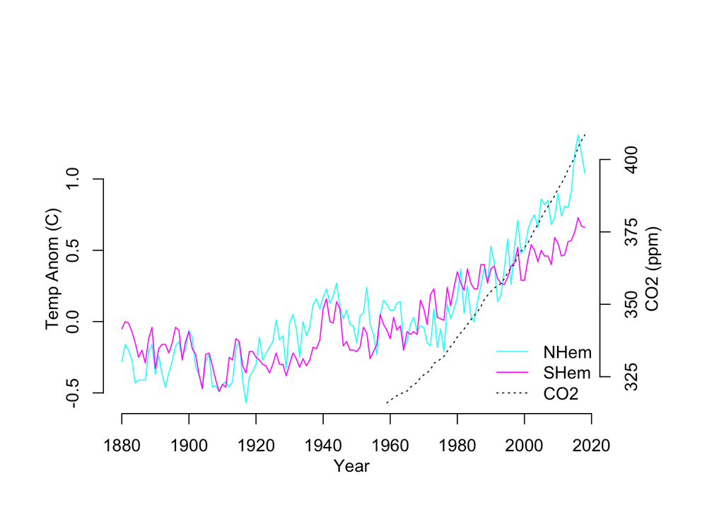

```r
mlo <- read.table("ftp://aftp.cmdl.noaa.gov/products/trends/co2/co2_annmean_mlo.txt", skip=57)
colnames(mlo) <- c("Year", "CO2","Unc")

par(oma=c(0,1,1,3), mar=c(5,4,5,3))
    plot(temps$Year, temps$NHem, type='l', axes=F, xlab='', ylab='', col="cyan",
         xlim=c(1880, 2017))
    axis(1, seq(1880, 2020, by=20))
    mtext(side=1, "Year", line=2)
    axis(2, seq(-0.5, 1.3, by=0.5))
    mtext(side=2, "Temp Anom (C)", line=2)

    lines(temps$Year, temps$SHem, col="magenta")

par(new=TRUE)
    plot(mlo$Year, mlo$CO2, lty=3, type='l', col="grey10", axes=F, xlab='',
         ylab='', xlim=c(1880, 2017))
    axis(4, seq(325, 400, by=25))
    mtext(side=4, "CO2 (ppm)", line=2)

    legend(x="bottomright", legend=c("NHem", "SHem", "CO2"),
           col= c("cyan", "magenta", "grey10"), lty=c(1,1,3), bty="n", xjust=-2)
```

#### Publication Quality Files

Should be overwritten each time to prevent too many versions. Settings can easily be changed to write to pdf() or other format depending on requirements for publication.

```r
ppi=300
png("/products/NASAGISS.png", width=8*ppi, height=6*ppi, res=ppi)

par(oma=c(0,1,1,3), mar=c(5,4,5,3))
    plot(temps$Year, temps$NHem, type='l', axes=F, xlab='', ylab='', col="cyan",
         xlim=c(1880, 2017))
    axis(1, seq(1880, 2020, by=20))
    mtext(side=1, "Year", line=2)
    axis(2, seq(-0.5, 1.3, by=0.5))
    mtext(side=2, "Temp Anom (C)", line=2)

    lines(temps$Year, temps$SHem, col="magenta")

par(new=TRUE)
    plot(mlo$Year, mlo$CO2, lty=3, type='l', col="grey10", axes=F, xlab='',
         ylab='', xlim=c(1880, 2017))
    axis(4, seq(325, 400, by=25))
    mtext(side=4, "CO2 (ppm)", line=2)

    legend(x="bottomright", legend=c("NHem", "SHem", "CO2"),
           col= c("cyan", "magenta", "grey10"), lty=c(1,1,3), bty="n", xjust=-2)
dev.off()
```

Always reset the graphical parameters to the default (or use the paintbrush button in Rstudio)

```r
par <- par(def.par)
```

#### Key Points

- Base R allows for very fine control of plots. But can take some time to develop.

#### **Acknowledgments**

_These pages were derived in part from: https://www.statmethods.net/advgraphs/layout.html_